# Cross-country spillovers from the regional core (stage 2d)

Six entities, three policy rules — the most seed-reproducible battery in this project, and the one shock that does not work

## 1. What this is

The battery `reports/stage2c_spillovers.qmd` runs, re-run on the **stage 2d** system: six entities (`de`, `fr`, `it`, `us`, `cn`, `reu`), stage 2c’s equations unchanged, `k = 46` against `T = 78`, **`df = 32`**.

That `df` is the reason to read this report. Stage 2b and 2c both ran at `df = 22` and `CLAUDE.md` records what that cost: re-running the *same* battery on the *same* fit at a different seed moved an off-diagonal spillover cell by 0.35pp on average for stage 2b, flipping the sign of 7–10 cells out of 30. Most of what anyone wanted to conclude from that matrix was smaller than its own noise. Stage 2d has half the equations and ten more degrees of freedom, and §3 measures what that buys.

koma has no impulse-response function, so every number here is the difference between two `koma::forecast()` calls — one unconditional, one restricted — paired by **common random numbers** (the same `set.seed()` immediately before each), so the difference isolates the shock rather than koma’s call-to-call forecast noise. Three shocks:

- **Demand**: `+1pp` on one entity’s GDP growth in the first forecast quarter only, after which GDP evolves under the model’s own dynamics.
- **Monetary**: `+100bp` held on a policy rate for four quarters.
- **Oil**: a `+50%` level shock to `oil_price`, which is exogenous and therefore cannot use `restrictions` at all — it needs a whole shocked copy of the fit.

The exogenous series had to be carried past the fit’s native forecast end first. koma silently shortens a horizon it cannot supply, so without this the battery would have returned fewer quarters than it claimed.

| variable | method | periods_added |
| --- | --- | --- |
| covid_2020q1 | zero (dummy) | 3 |
| covid_2020q2 | zero (dummy) | 3 |
| covid_2020q3 | zero (dummy) | 3 |
| covid_2021q2 | zero (dummy) | 3 |
| eur_usd | trailing-4Q avg growth (2.67%/q) | 3 |
| oil_price | trailing-4Q avg growth (1.41%/q) | 3 |
| row_gdp | trailing-4Q avg growth (0.44%/q) | 3 |

## 2. Demand spillovers

Cumulative 8-quarter GDP effect (pp) of a +1pp demand shock. Rows = shocked entity, columns = responding entity.

|  | de | fr | it | us | cn | reu |
| --- | --- | --- | --- | --- | --- | --- |
| de | 1.373 | 0.385 | 0.696 | 0.265 | 0.274 | 0.376 |
| fr | 1.123 | 1.387 | 1.162 | 0.443 | 0.442 | 0.837 |
| it | 0.664 | 0.400 | 1.208 | 0.265 | 0.332 | 0.486 |
| us | 0.834 | 0.454 | 0.605 | 1.155 | 0.220 | 0.703 |
| cn | 0.158 | 0.062 | 0.090 | 0.056 | 1.119 | 0.105 |
| reu | 0.827 | 0.608 | 0.964 | 0.495 | 0.479 | 1.398 |

spillover_sanity_checks() on the seed-A battery.

| check | ok | detail |
| --- | --- | --- |
| own effect exceeds every cross-country effect | TRUE | 6/6 countries: own > max\|cross\| |
| monetary contraction is negative for GDP and prices everywhere | FALSE | GDP peak negative: 6/6 \| prices peak negative: 1/6 |
| spillover magnitude correlates with bilateral trade weight | FALSE | Spearman rho = 0.138 (pass threshold: > 0.3) |

**`reu` behaves like a large country, not like a residual.** Its own effect (1.398) is the largest on the diagonal and its outward spillovers are comparable to Germany’s, which is what a bloc holding roughly a third of euro-area GDP should look like.

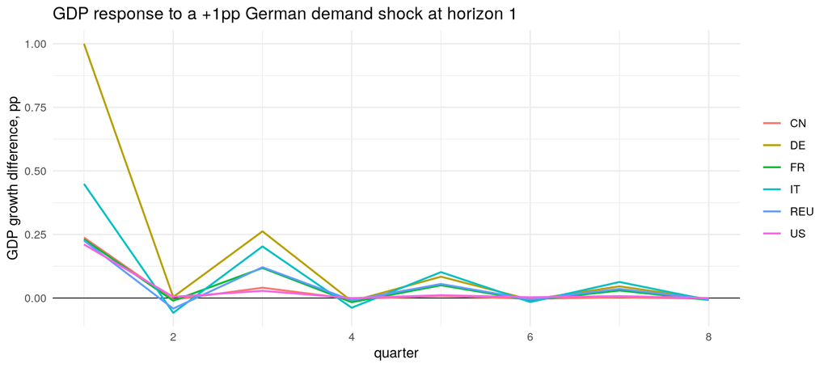

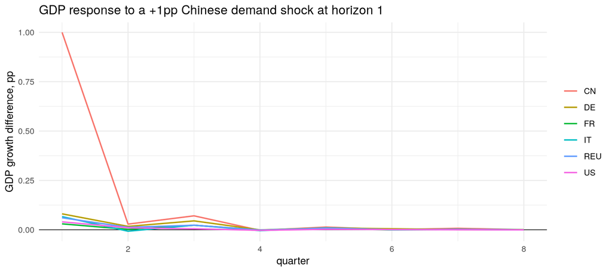

## 3. The seed placebo — and this is the headline

Before reporting that any of the above differs from stage 2b or 2c, the battery has to clear its own noise floor. 4 source entities were re-run at a second seed on the **same fit**, and the two matrices compared cell by cell.

Seed-to-seed movement of an off-diagonal spillover cell, same fit, different seed. Stage 2b and 2c figures from CLAUDE.md.

| System | Mean \|seed A - seed B\| | Max | Off-diagonal sign flips |
| --- | --- | --- | --- |
| stage 2b (df = 22) | 0.350 | 1.850 | 7-10 of 30 |
| stage 2c (df = 22) | 0.119 | 0.356 | 1 of 44 |
| **stage 2d (df = 32)** | **0.108** | **0.273** | **0 of 20** |

**0 sign flips out of 20**, a mean gap of 0.108pp and a worst case of 0.273pp. Stage 2c already improved on stage 2b by a factor of three; stage 2d improves on stage 2c again, and for the first time **no off-diagonal cell changes sign** when only the seed changes.

This is the strongest result in the stage-2d work, and it is strong precisely because it is a measurement *of* the noise rather than a claim made on top of it. It is also the concrete payoff of the re-partition: collapsing seven countries into a bloc was justified in `reports/stage2d_regional_core.qmd` on degrees of freedom alone, and this is what those ten extra degrees of freedom actually buy — a spillover matrix whose individual cells can be read, which neither of its predecessors’ could be.

Own-diagonal effects at both seeds.

| entity | seed_A | seed_B | gap |
| --- | --- | --- | --- |
| DE | 1.373 | 1.412 | -0.039 |
| US | 1.155 | 1.216 | -0.061 |
| CN | 1.119 | 1.208 | -0.089 |
| REU | 1.398 | 1.413 | -0.015 |

## 4. The monetary shock

### 4.1 The euro-area rule behaves

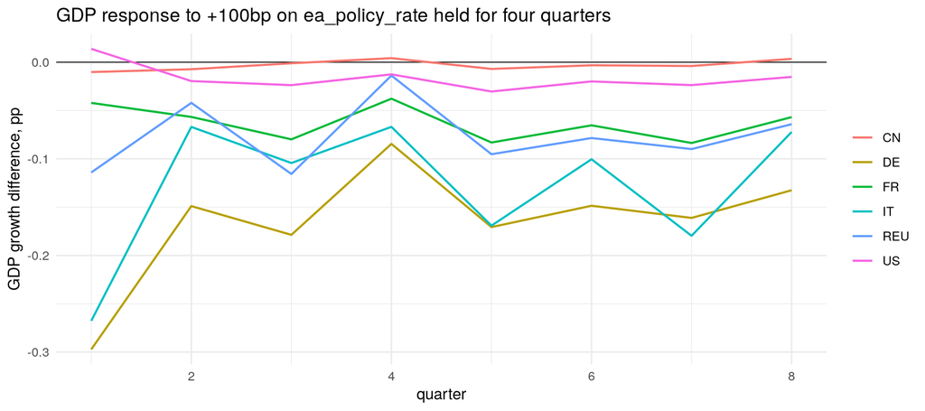

Cumulative and peak responses to the euro-area tightening, at both seeds.

| Entity | GDP cum. (seed A) | GDP cum. (seed B) | GDP peak (A) | Prices cum. (A) |
| --- | --- | --- | --- | --- |
| CN | -0.025 | 0.036 | -0.010 | 0.000 |
| DE | -1.322 | -1.226 | -0.297 | 0.544 |
| FR | -0.505 | -0.360 | -0.084 | 0.046 |
| IT | -1.027 | -0.768 | -0.268 | 0.324 |
| REU | -0.613 | -0.296 | -0.116 | 0.185 |
| US | -0.131 | 0.116 | -0.030 | 0.002 |

**GDP is correctly signed and the transmission is orderly.** Every entity’s peak GDP response is negative, the euro-area members most of all (-1.32pp cumulative for Germany, -1.03 for Italy), and the long rate tracks the policy rate essentially one-for-one, as the spread identity imposes. The two entities outside the euro area show the smallest responses and are **not** robust to the seed — the US goes from -0.131 to +0.116 and China from -0.025 to +0.036, crossing zero in both cases. Read those two as indistinguishable from nothing, which is the economically sensible answer anyway.

**Prices are still wrong-signed, and that is inherited, not new.** Only 1 of 6 entities show a negative price peak under a tightening. Stage 2c reported exactly this failure across all eleven countries and diagnosed it: the policy rate’s route into GDP is dominated by the horizon-1 simultaneity echo rather than a lagged demand channel, so the Phillips curve is fed a positive output impulse in the same quarter the rate rises. The re-partition does not touch that mechanism, so it does not fix it. The oil shock in §5 is the control that localises the fault to the *policy-rate* route rather than to the price block itself.

A sustained restriction makes some draws fail outright. koma drops them by subsetting the list, recording nothing about which index, so scenario_diff() refuses to difference legs of unequal length; failed_restriction_draws() recovers the indices by tracing koma:::forecast_draw() and the baseline is re-paired against exactly those.

| quantity | value |
| --- | --- |
| posterior draws attempted | 1000 |
| draws that failed the restriction | 25 |
| share | 2.5% |
| baseline draws dropped to re-pair | 25 |

### 4.2 The Chinese policy rate shock does not work

China’s own response to +100bp on cn_policy_rate, by horizon.

| variable | h1 | h2 | h3 | h4 | h5 | h6 | h7 | h8 |
| --- | --- | --- | --- | --- | --- | --- | --- | --- |
| cn_policy_rate | 1.006 | 0.994 | 1.003 | 0.991 | 0.745 | 0.626 | 0.421 | 0.380 |
| cn_long_rate | 1.482 | 1.590 | 1.724 | 1.733 | 1.435 | 1.251 | 0.990 | 0.871 |
| cn_prices | 1.375 | 0.798 | 0.733 | 0.460 | 0.296 | 0.122 | 0.091 | 0.035 |
| cn_domestic_demand | 7.391 | 0.012 | 0.833 | 0.183 | 0.025 | -0.001 | -0.034 | 0.009 |
| cn_gdp | 6.669 | 0.267 | 0.953 | 0.219 | 0.033 | 0.016 | -0.002 | 0.012 |

**This is a negative result and it should be read as one.** A +100bp Chinese tightening *raises* Chinese GDP by 6.67pp in the first quarter and by 8.17pp cumulatively — the wrong sign, and far too large.

Nothing pushes back the other way, because China’s demand channel is empty: `cn_domestic_demand`’s loading on `cn_long_rate` is -0.0188, with a 90% interval straddling zero. And that in turn traces to the data: `cn_long_rate` is **spliced over 45% of the estimation window** (OECD’s Chinese 10-year yield starts only 2014Q1), so before 2014 it moves exactly like the three-month interbank rate and carries no independent term-premium variation for the equation to identify against.

The euro-area rule does not have this problem because `ea_policy_rate` responds to `ea_gdp` and `ea_prices`, which are identities over four entities — the adjustment is spread across the whole area rather than loaded onto one country.

**Do not use `cn_policy_rate` as a monetary experiment in this system.** If a Chinese monetary channel is what you need, the place to start is `stage2d_config(spread_countries = setdiff(stage2d_countries(), "cn"))`, which drops the spliced long rate and lets Chinese demand load the complete, unspliced `IRSTCI` policy rate directly.

## 5. The oil shock

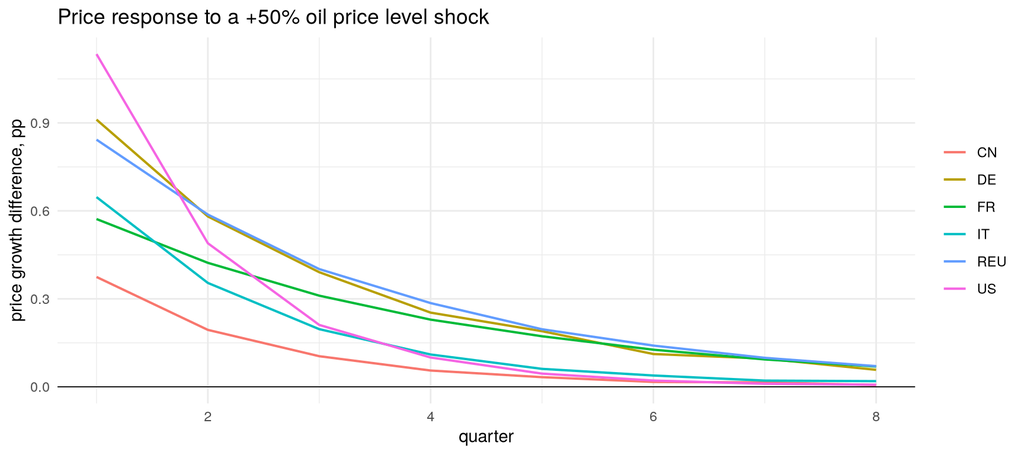

Cumulative response to a +50% oil price shock.

| Entity | Prices cum. (pp) | GDP cum. (pp) |
| --- | --- | --- |
| CN | 0.798 | -0.031 |
| DE | 2.591 | -1.031 |
| FR | 1.996 | -0.466 |
| IT | 1.447 | -0.786 |
| REU | 2.623 | -0.634 |
| US | 2.018 | -0.388 |

**Correctly signed in 6 of 6**, at 0.8–2.6pp cumulative — the same result stage 2c got, and the control that matters for §4. The price block responds sensibly to a **cost** shock and perversely to a **policy rate**, which localises the monetary failure to the policy rate’s route into the system rather than to the price equations themselves.

China’s price response (0.80pp) is the smallest, which is plausible: Chinese consumer prices are heavily food-weighted and administered energy pricing damps pass-through.

## 6. What still fails

The trade-weight check.

| check | ok | detail |
| --- | --- | --- |
| spillover magnitude correlates with bilateral trade weight | FALSE | Spearman rho = 0.138 (pass threshold: > 0.3) |

Share of baseline draws that are explosive, by horizon. Every number in this report is a median over the draws that survive this filter; a cell whose share is large is one whose spillover is estimated from a shrinking sample.

| variable | explosive_frac.1 | explosive_frac.2 | explosive_frac.3 | explosive_frac.4 | explosive_frac.5 | explosive_frac.6 | explosive_frac.7 | explosive_frac.8 |
| --- | --- | --- | --- | --- | --- | --- | --- | --- |
| de_gdp | 0.023 | 0.095 | 0.181 | 0.252 | 0.304 | 0.346 | 0.373 | 0.406 |
| fr_gdp | 0.017 | 0.076 | 0.142 | 0.217 | 0.274 | 0.310 | 0.356 | 0.377 |
| it_gdp | 0.047 | 0.126 | 0.213 | 0.283 | 0.332 | 0.370 | 0.409 | 0.437 |
| us_gdp | 0.020 | 0.079 | 0.153 | 0.219 | 0.287 | 0.331 | 0.352 | 0.384 |
| cn_gdp | 0.035 | 0.112 | 0.199 | 0.253 | 0.323 | 0.355 | 0.382 | 0.410 |
| reu_gdp | 0.015 | 0.091 | 0.166 | 0.243 | 0.288 | 0.329 | 0.364 | 0.390 |

## 7. Verdict

[output not shown]

Use this system for **demand** spillovers between the euro area, the US and China, where the matrix is now reproducible enough to read cell by cell, and for **cost-push** experiments. Do not use it for a monetary experiment on China, and treat any price response to a policy rate — in this stage or its predecessors — as unresolved.